# Anuj Ajwani July 2018 Version Titanic Project_Adapted as Work Sample

## Question to Answer:

The focus of this analysis is to identify the most important factors leading to survival during the Titanic disaster. Thus the basic question to answer is:

What factors and what specific values for those specific factors maximized the odds of survival?

## Key Findings

The analysis below shows that 'Sex', 'Pclass' (and other variables related to wealth) are the dominant factors that determined survival. In the case of 'Sex' and 'Pclass', both factors appeared to have a substantial impact as the tables and graphics below show. In addition to these, very young age also appears to be a slight factor that improved the odds of survival.

The factors that lead to enhanced rates of survival seem plausible, rather than just being spurious features of the data, in that they seem to reflect the social conventions and economic dimensions of the period. However, since we have limited information on how this information was collected and do not know if the collection might be biased in some way, it is prudent to not draw strong conclusions about the factors that led to survival. This is particularly so in the case of the variable 'Age' since in that case there were a lot of missing values and the link or trend between age and survival is very weak as noted below. The Chi Square test done below also comes with limitations in that the data does not easily avail itself to statistical inference techniques.

However, even with these limitations, the analysis, the Chi Square tests, and the visualizations below provide key insights that can be valuable to understand what shaped outcomes.

## Approach and Assumptions:

The data on the 891 passengers of the Titanic ship is being treated as data on a specific population rather than as a sample of a larger population. This is because the sample of 891 is simply too large to take without replacement from a population of the original 2224 (10% is considered a maximum) for many statistical inference techniques to be used meaningfully. Although, one might view this Titanic data as a sample of a larger fictional population of passengers who are faced with a similar disaster, such an approach seems contrived.

Similarly, since there is limited information on whether the observations on each of the passengers is independent from other passengers or whether this data conforms to sampling methods that minimize sampling bias, statistical inference is unlikely to provide particularly insightful knowledge.

To that effect, the goal of this analysis is to largely investigate the data from various angles, and gain insight and intuition on the factors that led to survival rather than to conduct many statistical tests. However, two Chi Square tests of independence will be conducted below for illustrative purposes to gain insight on the relationship between 'Sex' and survival on the one hand and 'Pclass' (ticket class) and survival. As the analysis below will make clear, the variable 'Sex' and others indicative of wealth such as 'Pclass', 'Fare', probably played a significant role in shaping the odds of survival and thus the analysis below focuses on those factors.

In addition, there is a brief exploration of the 'Age' variable, with an aim towards gaining insight into how it might have shaped the odds of survival.

## Extracting and Organizing the Data

A first step in the analysis is to extract the data from the relevant CSV file and place it in a format that will make it easy to explore and manipulate. An initial step in the cell below is to load the data into a pandas dataframe called "FullListDF". Printing the length of this dataframe indicates that there is one row per passenger.

A description of the dataset and each of the variables is available on the following website: https://www.kaggle.com/c/titanic/data

```python
import matplotlib.pyplot as plt
import matplotlib
matplotlib.style.use('ggplot')

import numpy as np
import pandas as pd
import csv

FullListDF = pd.read_csv('titanic-data.csv.htm')
print (len(FullListDF))
```

```
891
```

## Cleaning the Data and Dealing with Missing Values

In the case of three variables, specifically, 'Age', 'Cabin', and 'Embarked' there are missing values for some passengers with regard to these variables (The computer code and resulting data to extract the number of missing values is not shown here for the sake of brevity).

In the case of 'Embarked' only two passengers have missing values. Since this is a categorical variable that is non-binary no transformation of this variable onto a quantitative scale is being done.

Any transformation would involve specific choices of values for each Embarking point and these need to be weighed carefully and might not always be justifiable lest they bias any outcomes or insight. To that effect no transformation is being done. Since the number of passengers that have missing values is so small one could simply remove the passengers without a substantial effect. However, since the two passengers have all the other data (such as Age, Fare, Cabin) available it makes sense to leave them in place so the other data points regarding those passengers inform the analysis.

In the case of 'Cabin' 687 out of 891 passengers have missing values. Removing all of these passengers from the data set is not a practical option to do a nuanced and robust analysis. In instances where the 'Cabin' variable has entries the data is essentially categorical in nature even if numbers are used. Thus, quantitative methods are not easily applied to that data without additional steps to transform the data.

For the variable 'Sex' values for 'male' will be changed to 0 and for 'female' to 1 so as to facilitate easier quantitative manipulation.

A variable 'Count' is also created with a value of 1 for each passenger so as to aid analysis when counting the number of passengers in some instances.

```python
#Creating 'Count' variable to assist with analysis
FullListDF['Count'] = 1

#Changing variable 'Sex' into binary quantitative form to aid analysis
FullListDF['Sex'].replace({'male':0.0, 'female':1.0}, inplace = True)
```

## Dealing with Missing Values of Age

With respect to the variable 'Age' 177 values are missing. The lack of data on such a large number of passengers means that it is best to simply not remove the passengers with the missing values.

A very brief comparison (albeit not one with statistical methods or tests) which will be shown below suggests that the population with missing values for Age is different in some respects than the population for which Age is available. Thus removing the passengers with missing values might make the data set and resulting analysis less nuanced.

Thus these passengers with missing values for age will be kept in the data, but the median age of the rest of the population (28.0) will be placed as a value. This is done by creating a new variable called 'AgeNoMissValues' in which missing values will have the age of 28.0.

```python
#Creating a new variable 'AgeNoMissValues'
FullListDF['AgeNoMissValues'] = FullListDF['Age']
FullListDF['AgeNoMissValues'].fillna(value = FullListDF['AgeNoMissValues'].median(),inplace = True)
```

## Comparison -- Passengers with Age Values vs. Age Values Missing

As the output resulting from the cell below shows, the mean metrics for passengers for whom Age was missing differ in several respects from the mean metrics of passengers for whom the data was available. On average the passengers in the former category survived at a lower rate (29% vs. 41%), were a lower class (2.6 vs. 2.24), had lower ticket fares(22.15 vs. 34.7), and were less likely to be women (30% vs 37%).

Since there is the possibility that the population with missing values is different from the population for which we have values one cannot place high confidence in any replacement number (i.e. mean or some other predicted value of Age based on regression or some other method) derived from the passengers for which Age is available. To that effect the variable 'AgeNoMissValues' will be used cautiously and any conclusions derived from it need to be caveated appropriately.

```python
FullListDF['age_missing_values'] = FullListDF['Age'].isnull()
FullListDF.groupby('age_missing_values')['Survived','Pclass','Fare','Sex'].agg([np.mean, np.sum])
```

| age_missing_values | Survived mean | Survived sum | Pclass mean | Pclass sum | Fare mean | Fare sum | Sex mean | Sex sum |
| --- | --- | --- | --- | --- | --- | --- | --- | --- |
| False | 0.406162 | 290 | 2.236695 | 1597 | 34.694514 | 24771.8830 | 0.365546 | 261.0 |
| True | 0.293785 | 52 | 2.598870 | 460 | 22.158567 | 3922.0663 | 0.299435 | 53.0 |

## Correlation with 'Survived'

The result from the cell below shows the correlation of the 'Survived' variable with other quantitative variables. This is a useful way to gain a quick snapshot of possible linear relationships that can guide further analysis. This is not however intended to be the only exploratory method used on the data.

The readout below shows that the 'Survived' variable, has the highest absolute correlations with the 'Sex', 'Pclass', and 'Fare' variables. These seem plausible and not the result of spurious correlation. The relatively high positive correlation between 'Sex' and 'Survived' is likely the result of the social conventions of the time of the disaster that likely gave priority to women disembarking safely.

The positive correlation between 'Fare' and 'Survived' is likely the result of wealthier passengers having better opportunities to disembark safely. A similar reason is likely behind the relatively high negative correlation between 'Pclass' and 'Survived' since higher class (A 'higher' class has a smaller class number -- i.e. 1 is higher class than 2) passengers were more likely to survive.

```python
FullListDF.corr()['Survived']
```

```
PassengerId          -0.005007
Survived              1.000000
Pclass               -0.338481
Sex                   0.543351
Age                  -0.077221
SibSp                -0.035322
Parch                 0.081629
Fare                  0.257307
Count                      NaN
AgeNoMissValues      -0.064910
age_missing_values   -0.092197
Name: Survived, dtype: float64
```

## Comparison between Male and Female Passengers

The cell below uses Pandas' groupby and aggregate functions to display the mean and sum of some quantitative metrics for male and female passengers separately. The table output provides basic data to compare some characteristics and outcomes for male and female passengers.

As is apparent, male and female passengers survived at a starkly different rate. The count column indicates that there were 577 males and 314 females and that the survival rate for men was approximately 19%, but more than 74% for females. The cell further below segments male and female passengers on the basis of whether they survived or not. The sum column under the 'Count' variable in the display from that cell provides an instructive breakdown of the percentages noted above -- 468 male passengers did not survive while 109 did and only 81 female passengers did not survive while more than 233 did.

Another notable aspect of the display from the cell following the one below is the difference in means for some metrics between those who survived and those who did not -- For both males and females on average 'Pclass' was higher for the survivors by a relatively large margin highlighting the role wealth played in survival.

```python
GroupedbySex = FullListDF.groupby(['Sex'])
GroupedbySex['Survived','Pclass','Age','Fare','Count'].agg([np.mean, np.sum])
```

| Sex | Survived mean | Survived sum | Pclass mean | Pclass sum | Age mean | Age sum | Fare mean | Fare sum | Count mean | Count sum |
| --- | --- | --- | --- | --- | --- | --- | --- | --- | --- | --- |
| 0.0 | 0.188908 | 109 | 2.389948 | 1379 | 30.726645 | 13919.17 | 25.523893 | 14727.2865 | 1 | 577 |
| 1.0 | 0.742038 | 233 | 2.159236 | 678 | 27.915709 | 7286.00 | 44.479818 | 13966.6628 | 1 | 314 |

```python
GroupedbySex_Survived = FullListDF.groupby(['Sex', 'Survived'])
GroupedbySex_Survived['Pclass','Age','Fare','Count'].agg([np.mean, np.sum])
```

| Sex | Survived | Pclass mean | Pclass sum | Age mean | Age sum | Fare mean | Fare sum | Count mean | Count sum |
| --- | --- | --- | --- | --- | --- | --- | --- | --- | --- |
| 0.0 | 0 | 2.476496 | 1159 | 31.618056 | 11382.50 | 21.960993 | 10277.7447 | 1 | 468 |
|  | 1 | 2.018349 | 220 | 27.276022 | 2536.67 | 40.821484 | 4449.5418 | 1 | 109 |
| 1.0 | 0 | 2.851852 | 231 | 25.046875 | 1603.00 | 23.024385 | 1864.9752 | 1 | 81 |
|  | 1 | 1.918455 | 447 | 28.847716 | 5683.00 | 51.938573 | 12101.6876 | 1 | 233 |

## Impact of Ticket Class

As the display from the cell below shows, the survival rate declines consistently with the ticket class. When segmented further by 'Sex' and 'Pclass' as the display from the cell further below shows, the downward trend for each of the sexes is not as smooth as the trend in the cell right below. For males, there is a dropoff in survival rate from 1st class to 2nd, but not a substantial dropoff from 2nd to 3rd. For females, there is not much of a drop off from 1st to 2nd class, but a substantial one from 2nd to 3rd. Thus the first table below masks to an extent the sharp differences in within classes of male and female survival rates.

The granularity of information in the 'Pclass' and 'Sex' table thus highlights the importance of taking into account the impact of 'Sex' on any analysis one does related to ticket class or other variables that are a proxy for passenger wealth.

```python
GroupedbySex_Pclass = FullListDF.groupby(['Pclass'])
GroupedbySex_Pclass['Survived','Sex','Age','Fare','Count'].agg([np.mean, np.sum])
```

| Pclass | Survived mean | Survived sum | Sex mean | Sex sum | Age mean | Age sum | Fare mean | Fare sum | Count mean | Count sum |
| --- | --- | --- | --- | --- | --- | --- | --- | --- | --- | --- |
| 1 | 0.629630 | 136 | 0.435185 | 94.0 | 38.233441 | 7111.42 | 84.154687 | 18177.4125 | 1 | 216 |
| 2 | 0.472826 | 87 | 0.413043 | 76.0 | 29.877630 | 5168.83 | 20.662183 | 3801.8417 | 1 | 184 |
| 3 | 0.242363 | 119 | 0.293279 | 144.0 | 25.140620 | 8924.92 | 13.675550 | 6714.6951 | 1 | 491 |

```python
GroupedbySex_Pclass = FullListDF.groupby(['Pclass', 'Sex'])
GroupedbySex_Pclass['Survived','Age', 'Fare', 'Count'].agg([np.mean, np.sum])
```

| Pclass | Sex | Survived mean | Survived sum | Age mean | Age sum | Fare mean | Fare sum | Count mean | Count sum |
| --- | --- | --- | --- | --- | --- | --- | --- | --- | --- |
| 1 | 0.0 | 0.368852 | 45 | 41.281386 | 4169.42 | 67.226127 | 8201.5875 | 1 | 122 |
|  | 1.0 | 0.968085 | 91 | 34.611765 | 2942.00 | 106.125798 | 9975.8250 | 1 | 94 |
| 2 | 0.0 | 0.157407 | 17 | 30.740707 | 3043.33 | 19.741782 | 2132.1125 | 1 | 108 |
|  | 1.0 | 0.921053 | 70 | 28.722973 | 2125.50 | 21.970121 | 1669.7292 | 1 | 76 |
| 3 | 0.0 | 0.135447 | 47 | 26.507589 | 6706.42 | 12.661633 | 4393.5865 | 1 | 347 |
|  | 1.0 | 0.500000 | 72 | 21.750000 | 2218.50 | 16.118810 | 2321.1086 | 1 | 144 |

## Visualization of Survival Rates by 'Sex' and 'Pclass'

The bar chart below shows the survival rate of males and females segmented by ticket class and underscores the points made above on the impact of both 'Sex' and 'Pclass' on survival rates.

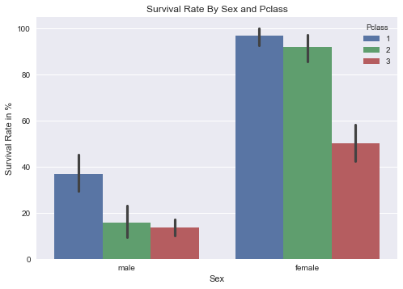

```python
import seaborn as sns
sns.barplot(x = 'Sex', y = 'Survived', hue = 'Pclass', data = FullListDF)
plt.xlabel('Sex')
plt.xticks(range(0,2), ['male', 'female'])
plt.title('Survival Rate By Sex and Pclass')
plt.ylabel('Survival Rate in %')
plt.yticks(np.arange(0, 1.1, 0.2), range(0,101,20))
plt.show()
```

## Chi Square Tests of Independence

In the cell below is code that undertakes a Chi-square test of independence on the 'Sex' and 'Pclass' variables. Generally such tests are conducted on samples rather than populations. The typical aim of such a test is to gain insight into whether two or more variables are independent of one another in a population of which we generally only have a sample.

When two variables are being tested, the question one seeks to answer is whether the response on one variable influences the response on another variable in the population. In the case of the impact of 'Sex' or 'Pclass' on 'Survived', if the variables were independent, the survival rate would be similar across either 'Sex' or 'Pclass'.

If the p-value resulting from such a test on a sample is very low it means that it is highly unlikely that in the population, one variable has no impact or bearing on the other. It also means that the two variables in the population likely are not independent from each other and probably have to some extent a relationship or impact between them that is apparent in the sample.

A key difference between typical Chi Square tests and what is undertaken below is that, as explained above, this data set is essentially considered a population rather than a sample. When one has access to the data for an entire population, sample related methods are not as useful or essential in conducting analysis. Furthermore, as discussed above, if this population were to be treated as a sample, given our lack of insight into how the data was collected many statistical inference techniques cannot be meaningfully used on the data.

One of the assumptions when conducting Chi Square tests is that each observation (Passenger) is independent of each other. This statement will probably not be completely true in the case of this data set given the associations between passengers.

Given these limitations and the fact that the notional larger population does not really exist if one uses this data as a sample means that one cannot draw strong conclusions from any such test. Furthermore, different social and technological trends from the time of the Titanic disaster, and the idea that past trends might not be indicative of the present or future mean that one cannot really apply the lessons or insights gained without further due diligence and research.

Even with all these limitations, a Chi Square test can at a minimum illustrate how likely or unlikely it is for two variables in a notional larger population of which this data set might be considered a sample to behave like they did in this sample if the variables were truly independent of each other.

The hypotheses for the 'Sex' and 'Survived' variables (null followed by alternative hypothesis) are:

```
H0: 'Sex' and 'Survived' are independent
H1: 'Sex' and 'Survived' are dependent
```

The hypotheses for the 'Pclass' and 'Survived' variables (null followed by alternative hypothesis) are:

```
H0: 'Pclass' and 'Survived' are independent
H1: 'Pclass' and 'Survived' are dependent
```

A 95% confidence level is being used in each case.

Thus in each of the tests below a low p-value (lower than 0.05) would mean we can reject the null hypothesis at the 95% confidence level.

```python
from scipy.stats import chi2_contingency

# Grouping passengers' 'Survived' status by 'Sex' and 'Pclass' respectively
SexSurvival = FullListDF.groupby(['Sex'])['Survived']
PclassSurvival = FullListDF.groupby(['Pclass'])['Survived']

# Creating contingency tables for 'Sex' and 'Pclass' as each relates to 'Survived'
Sex_Survived_contingency_table = SexSurvival.value_counts().unstack()
Pclass_Survived_contingency_table = PclassSurvival.value_counts().unstack()

# Deriving respective p values for each of the variables
_, Sex_p_value, _, _ = (chi2_contingency(Sex_Survived_contingency_table))
_, Pclass_p_value, _, _ = (chi2_contingency(Pclass_Survived_contingency_table))

print ('Sex and Survived -- pvalue:{}'.format(Sex_p_value))

print ('Pclass and Survived -- pvalue:{}'.format(Pclass_p_value))
```

```
Sex and Survived -- pvalue:1.1973570627755645e-58
Pclass and Survived -- pvalue:4.549251711298793e-23
```

Both the tests above result in p-values much lower than 0.05. The p-value is the probability of coming up with the Chi Square statistic on a test if the null hypothesis were true and in general, the lower the p-value, the higher the confidence we can have in rejecting the null hypothesis as is the case in both the tests above.

The tests confirm what we know from investigating the data that both 'Sex' and 'Pclass' influenced survival. However, as the limitations above note, one cannot draw any substantial or strong conclusions about a notional larger population or future similar disasters without further due diligence.

## Lack of Notable Trends in 'Parch' and 'SibSp'

An analysis (not shown here) of the 'Parch' and 'SibSp' variables suggests a slight trend whereby the survival rate declines when either of the variables reaches a high number, but the trend appears to be influenced by factors such as 'Pclass'. Using the Pandas' groupby function to understand a notable trend in the case of 'Parch' and 'SibSp' did not reveal anything notable that was not also the function of 'Pclass' or 'Sex'.

## Creating Age Groups

The code in the cell below divides the passengers into four age groups with the first one including values greater than 0 up to and including 20, the second one is for ages greater than 20 up to and including 40, the third for ages greater than 40 up to and including 60, and the fourth is for ages greater than 60 and up to and including 85. The size and boundaries of the groups are arbitrary to some extent. The values in 'AgeNoMissValues' are being used and thus the second group will have all the passengers whose 'Age' information was missing.

The groups have been created to simply aid analysis by placing a large number of disparate age values into a smaller number of groups. The choice of placing passengers into four groups rather than two or three is largely arbitrary and can be changed. The size and number of the groups at times appears to affect the insight or trend that is visible -- something worth being cognizant of before drawing strong conclusions from this data. The cells below show that the survival rate has a largely downward trend as age increases, although this is not smooth since group 3 has a higher survival rate (39%) than group 2(36%).

```python
age_groups = pd.cut(FullListDF['AgeNoMissValues'], [0,20,40,60,85], labels = range(1,5))
FullListDF.groupby(age_groups).agg([np.mean, np.sum])['Survived']
```

| AgeNoMissValues | mean | sum |
| --- | --- | --- |
| 1 | 0.458101 | 82 |
| 2 | 0.364769 | 205 |
| 3 | 0.390625 | 50 |
| 4 | 0.227273 | 5 |

## Scatter Plots for Age Groups and Age

Below are two graphics that might provide intuitive understanding. Both the 'age_groups' and 'AgeNoMissValues' will be used to create visuals below. The 'age_group' data can provide an overview of the broad trend and the 'AgeNoMissValues' of which there are many entries, provides a more nuanced picture of the trend.

The first one right below shows the survival rate for each of the groups and the size of the circles reflects the number of passengers in that specific Age Group. As the scatter plot shows, there is a downward trend to the survival rate by age group. However, the trend is not smooth given group 3 has a slightly greater survival rate than group two. However, the trend largely holds.

The second visualization further below shows the same information but for the 'AgeNoMissValues' variable. Further analysis of the scatter plot follows below.

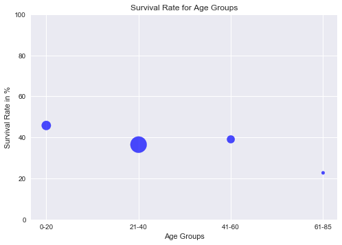

```python
AG = FullListDF.groupby(age_groups)['Survived'].agg([np.mean, len]).reset_index()
plt.scatter(AG['AgeNoMissValues'], AG['mean'], s = AG['len'], alpha = 0.7, color = 'blue')
plt.title('Survival Rate for Age Groups')
plt.ylabel('Survival Rate in %')
plt.xlabel('Age Groups')
plt.xticks(range(1,5),['0-20', '21-40', '41-60', '61-85'])
plt.yticks(np.arange(0, 1.1, 0.2), range(0,101,20))
plt.show()
```

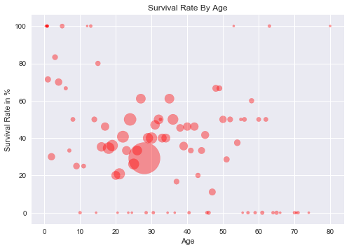

```python
M = FullListDF.groupby(['AgeNoMissValues'])['Survived'].agg([np.mean, len]).reset_index()
plt.scatter(M['AgeNoMissValues'], M['mean'], s = M['len']*10, alpha = 0.4, color = 'red')
plt.title('Survival Rate By Age')
plt.ylabel('Survival Rate in %')
plt.xlabel('Age')
plt.yticks(np.arange(0, 1.1, 0.2), range(0,101,20))
plt.show()
```

## Analysis of the Age Scatterplot

In the scatter plot above, there is a large circle for age 28 and that is essentially a reflection of assigning that value to all passengers whose Age was missing.

There is not a strong linear relationship apparent between the age and survival rate but a few points are worth noting and suggest that on average being a minor or under the age of 10 increased the odds of survival a bit. This holds for those under 20 as well but less so.

A dark red circle or circles on or near 100 on the y axis and on or near 0 on the x axis suggests that the very young had a relatively high survival rate. The darkness of that circle indicates that there are multiple circles around that age that survived at a relatively high rate. Close to that circle are a few other age groups under the age of 20 that survived at a high rate. In contrast moving to the right along the 'Age' axis there are smaller and lighter circles suggesting fewer and smaller groupings of advanced age survived at a high rate.

In the survival rate range from 70% and above, groupings of relatively younger passengers under age 20 are present, but there are not as many groupings/circles with such a high survival rate as the age increases above 20.

The opposite trend can be seen in the area of survival rate 0%. There are a few small and light circles in vicinity of age 20 and below that. Most of the circles, including larger ones, and ones that in part are darker red, indicative of multiple circles, are of ages 20 and above, and more so in the case of ages 40 and above. A similar trend holds for the circles present in the survival rate below 20%.

Further analysis of the above, after stripping out the effect of 'Pclass' and 'Sex' might provide more insight. However, on average, for the whole dataset, 'Age' is negatively correlated with 'Pclass' suggesting that lower class passengers were also generally younger, thus suggesting that these trends might remain in effect independent of the effect of 'Pclass'. However, further analysis would be needed to understand the trend as further segmented by 'Sex' and 'Pclass'.

Furthermore, it is important to underscore that this is a relatively weak trend and is also somewhat inconclusive given the missing values for 'Age' for so many passengers. However, it has been highlighted here as a relevant factor after 'Sex' and 'Pclass'(and wealth in general) as an additional factor shaping outcomes.

## Conclusion

The analysis above shows that 'Sex', 'Pclass' (and other variables related to wealth) are the dominant factors that determined survival. In the case of 'Sex' and 'Pclass', both factors appeared to have a substantial impact as the tables and graphics above show. In addition to these, very young age also appears to be a slight factor that improved the odds of survival.

The impact of these factors seems to reflect the social conventions and economic dimensions of the period. Since we have limited information on how this information was collected and do not know if the collection might be biased in some way, it is prudent to not draw strong conclusions about the factors that led to survival.